# Cuomo 2020 unsupervised learning practical

The single-cell RNA-seq data used in this example comes from the Cuomo et al 2020 paper (https://www.nature.com/articles/s41467-020-14457-z). The expression levels have been normalised using SCTransform (https://genomebiology.biomedcentral.com/articles/10.1186/s13059-019-1874-1). Here, we are only considering cells from day 3, coming from donors hayt, melw and naah. 500 (non-constant) genes have been selected at random to lower the time requirements. We will apply dimensionalitiy reduction methods and attempt to cluster the cells.

```r
library(tibble)
library(dplyr)
library(ggplot2); theme_set(theme_minimal())
library(GGally)
library(scales)
library(RColorBrewer)
library(Rtsne)
library(umap)
library(dendextend)

set.seed(2021)
```

## Loading data

Let’s first load the data. We split out the actual classes and we will ignore these for all unsupervised algorithms.

```r
cuomo = read.csv('data/Cuomo2020_ML.csv', row.names = 1)
cuomoData = cuomo[, colnames(cuomo)[colnames(cuomo) != 'classification']]
cuomoClass = as.factor(cuomo$classification)
```

Let’s also create a centered and z-transformed version of the data.

```r
cuomoDataCentered = scale(cuomoData, center = TRUE, scale = FALSE)
cuomoDataZtransformed = scale(cuomoData, center = TRUE, scale = TRUE)
```

## Part 1 - Dimensionality reduction

### PCA

Run a PCA on the dataset and plot the first two PCs. Optionally colour the points using the classes.

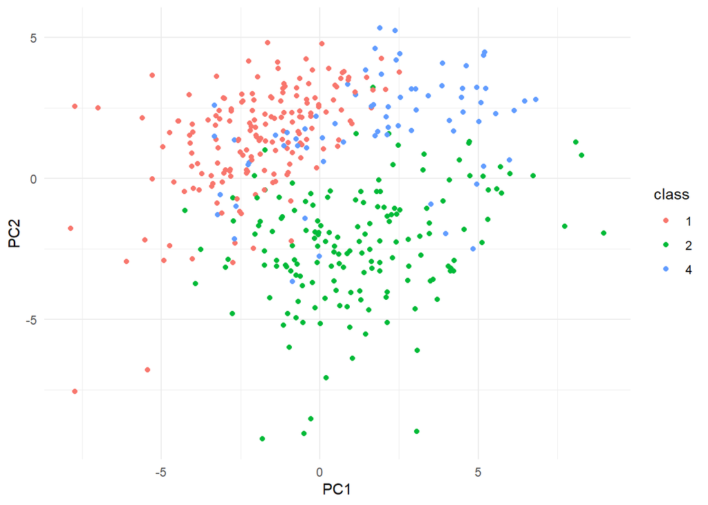

```r
pca <- prcomp(cuomoData, center = TRUE, scale = TRUE)
plot.df <- pca$x %>%
  as.data.frame() %>%
  mutate(class = cuomoClass)
ggplot(plot.df) +
  geom_point(aes(x = PC1, y = PC2, colour = class))
```

Plot the genes contributing most to PC1 in PCA space.

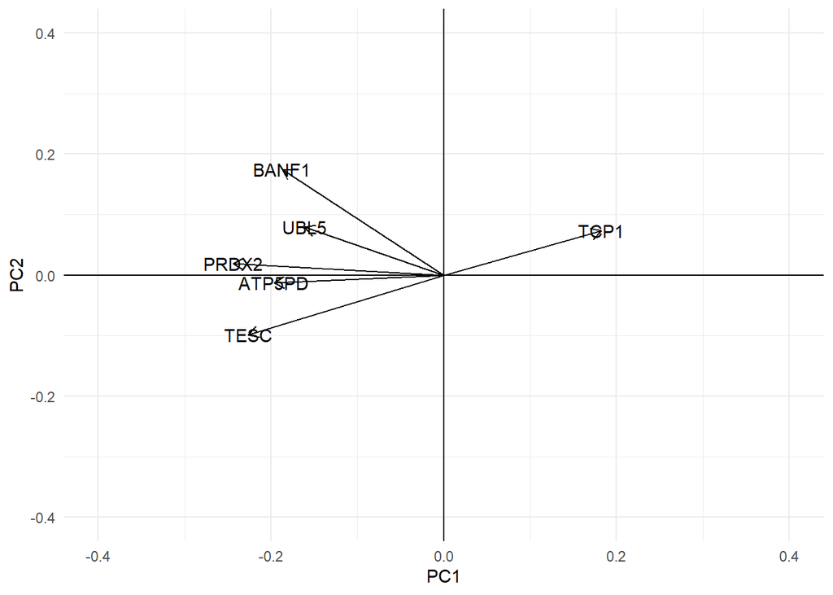

```r
plot.df <- pca$rotation %>%
  as.data.frame() %>%
  rownames_to_column(var = 'gene') %>%
  mutate(absPC1 = abs(PC1)) %>%
  arrange(desc(absPC1)) %>%
  head()

ggplot(plot.df) +
  geom_text(aes(x = PC1, y = PC2, label = gene)) +
  scale_x_continuous(limits = c(-0.4, 0.4)) +
  scale_y_continuous(limits = c(-0.4, 0.4)) +
  geom_hline(yintercept = 0) +
  geom_vline(xintercept = 0) +
  geom_segment( mapping = aes(x = 0, y = 0, xend = PC1, yend = PC2),
                arrow = arrow(length = unit(0.25, 'cm')), inherit.aes = FALSE)
```

### t-SNE

Run th t-SNE dimensionality reducion and plot the cells.

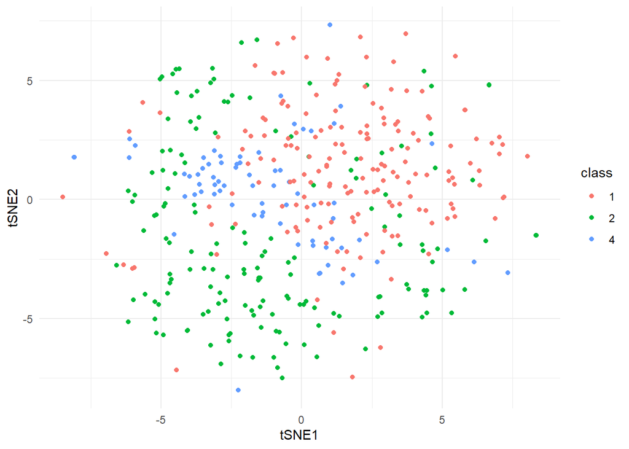

```r
tsne <- Rtsne(cuomoData, check_duplicates = FALSE, pca = TRUE, dims = 2)
plot.df <- tsne$Y %>%
  as.data.frame() %>%
  mutate(class = cuomoClass) %>%
  rename(tSNE1 = V1, tSNE2 = V2)
ggplot(plot.df) +
  geom_point(aes(x = tSNE1, y = tSNE2, colour = class))
```

### UMAP

Try UMAP, a different non-linear dimensionality reduction (hint: use the umap() function from the umap package).

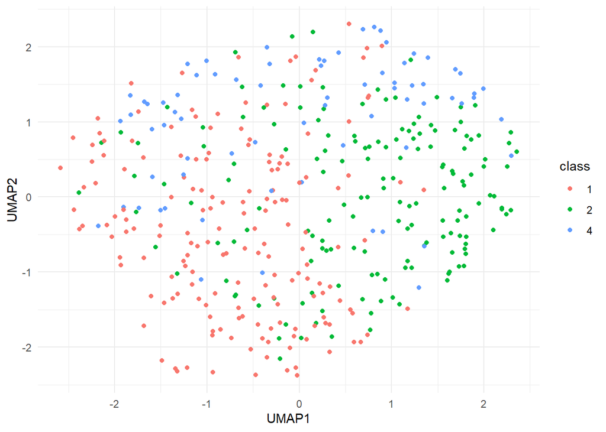

```r
umap <- umap(cuomoData)
plot.df <- umap$layout %>%
  as.data.frame() %>%
  mutate(class = cuomoClass) %>%
  rename(UMAP1 = V1, UMAP2 = V2)
ggplot(plot.df) +
  geom_point(aes(x = UMAP1, y = UMAP2, colour = class))
```

## Part 2

### Hierarchical clustering

Perform hierarchical clustering on the data. Try using the raw, centered, z-transformed, and pca-transformed data as input. What do you observe? What could you do to improve the results? (hint: use the PCA)

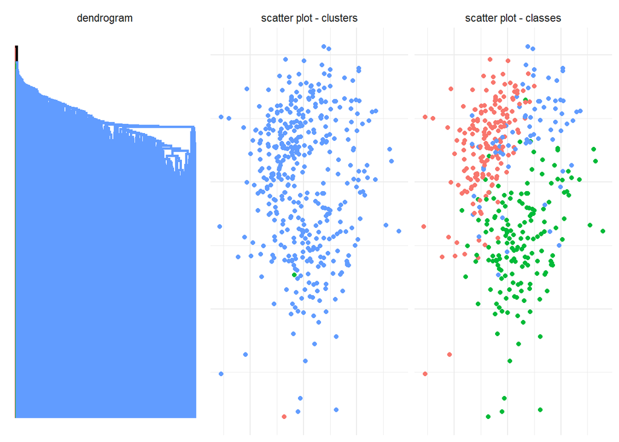

```r
perform_hierarchical_clustering <- function(data, n_clusters = 3){
  d <- dist(data)
  dend <- as.dendrogram(hclust(d, method = "average"))
  clusters <- cutree(dend, n_clusters, order_clusters_as_data = FALSE)
  dend <- color_branches(dend, clusters = clusters, col = hue_pal()(n_clusters))
  labels(dend) <- rep("", nrow(data))
  ggd <- as.ggdend(dend)
  ggd$nodes <- ggd$nodes[!(seq_len(length(ggd$nodes[, 1]))), ]
  clusters <- clusters[rownames(data)]
  plot.df <- pca$x %>%
    as.data.frame() %>%
    mutate(class = cuomoClass,
           cluster = as.factor(clusters))
  plotList <- list(
    ggplot(ggd),
    ggplot(plot.df) +
      geom_point(aes(x = PC1, y = PC2, colour = cluster)),
    ggplot(plot.df) +
      geom_point(aes(x = PC1, y = PC2, colour = class))
  )
  pm <- ggmatrix(
    plotList, nrow = 1, ncol = 3,
    showXAxisPlotLabels = FALSE, showYAxisPlotLabels = FALSE,
    xAxisLabels = c("dendrogram", "scatter plot - clusters", "scatter plot - classes")
  )
  pm
}
perform_hierarchical_clustering(cuomoData)
```

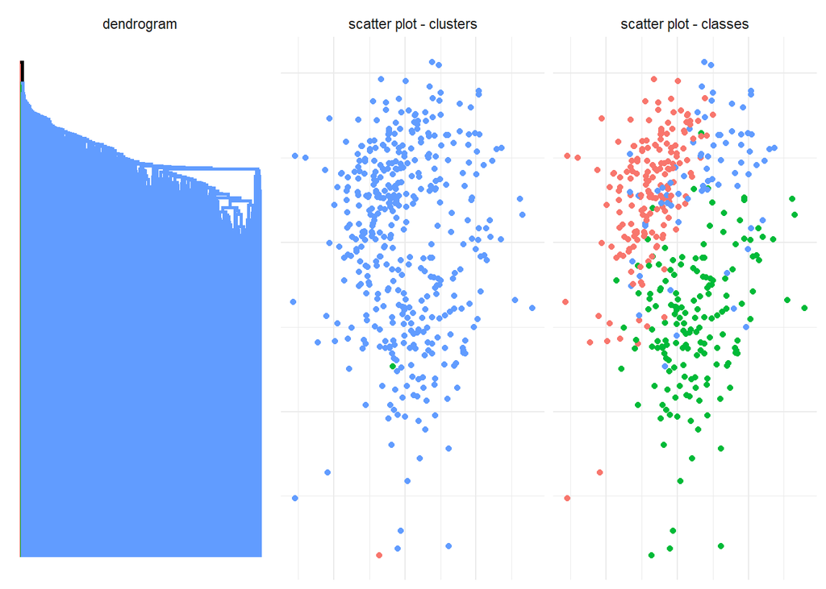

```r
perform_hierarchical_clustering(cuomoDataCentered)
```

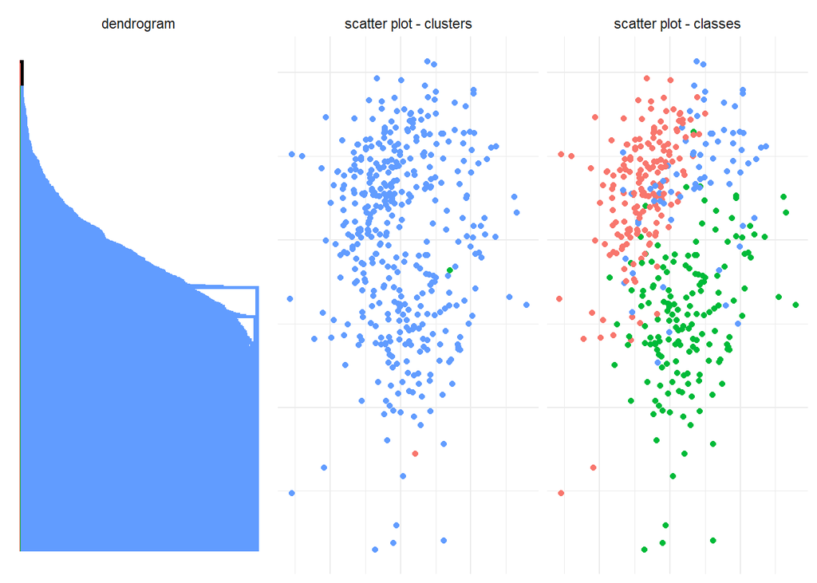

```r
perform_hierarchical_clustering(cuomoDataZtransformed)
```

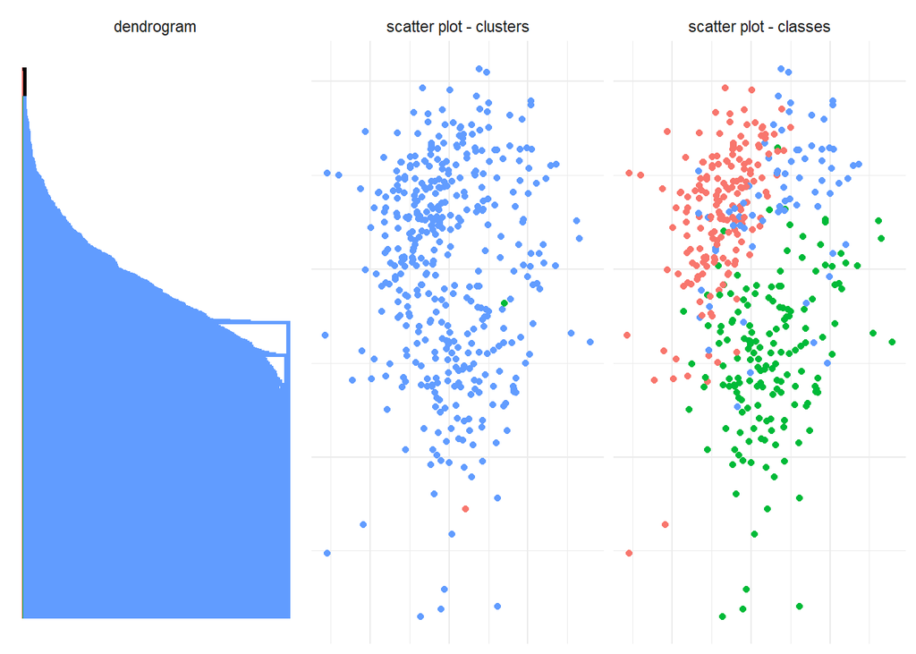

```r
perform_hierarchical_clustering(pca$x)
```

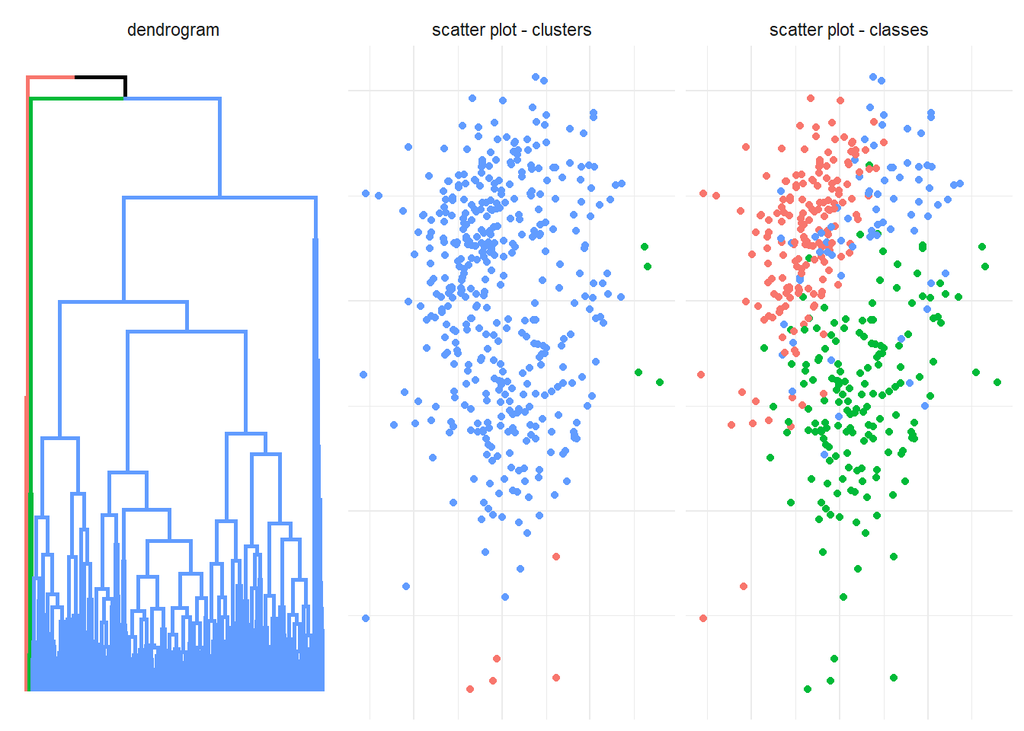

```r
perform_hierarchical_clustering(pca$x[, 1:2])
```

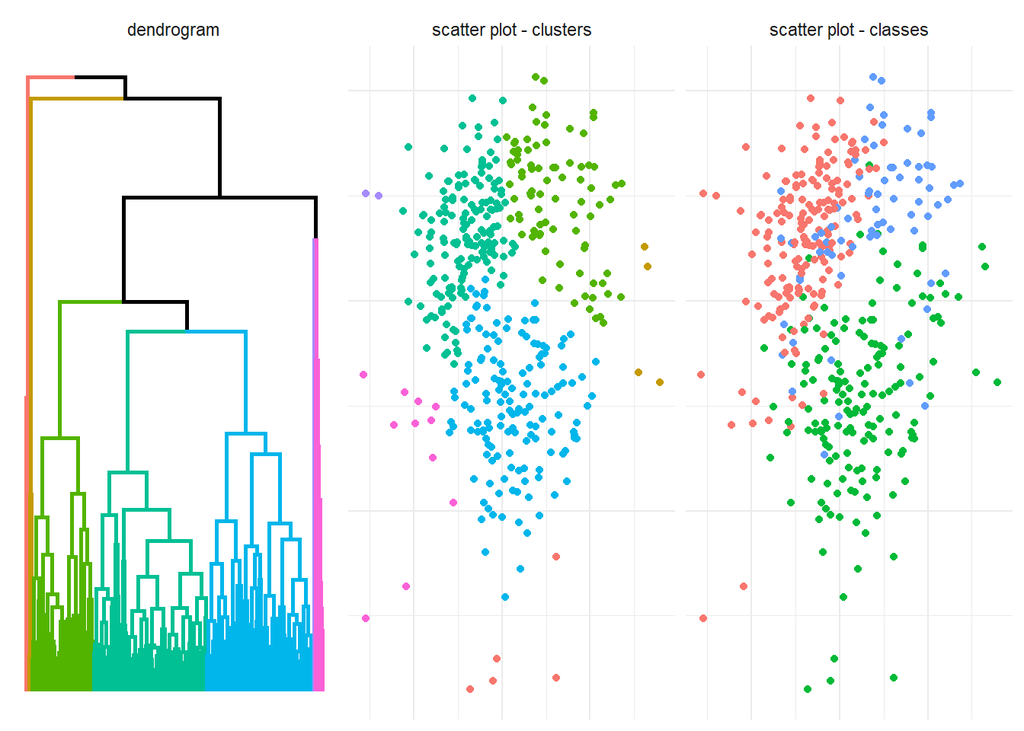

```r
perform_hierarchical_clustering(pca$x[, 1:2], n_clusters = 7)
```

### K-means

Run k-means for k=3 and plot the results. Try using the raw, centered, z-transformed, and pca-transformed data as input. Which input makes the algorithm perform better?

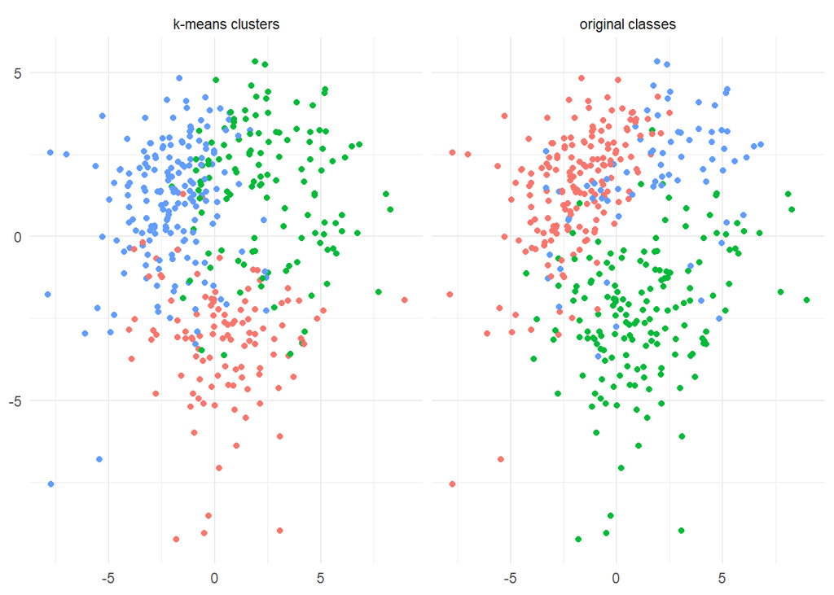

```r
kmR <- kmeans(cuomoData, 3, nstart = 50)
kmC <- kmeans(cuomoDataCentered, 3, nstart = 50)
kmZ <- kmeans(cuomoDataZtransformed, 3, nstart = 50)
kmP <- kmeans(pca$x, 3, nstart = 50)

plot_k_means_result_on_PCA <- function(km){
  plot.df <- pca$x %>%
    as.data.frame() %>%
    mutate(class = cuomoClass,
           cluster = as.factor(km$cluster))
  p1 <- ggplot(plot.df) +
    geom_point(aes(x = PC1, y = PC2, colour = cluster))
  p2 <- ggplot(plot.df) +
    geom_point(aes(x = PC1, y = PC2, colour = class))

  ggmatrix(list(p1, p2), nrow = 1, ncol = 2, xAxisLabels = c("k-means clusters", "original classes"))
}

plot_k_means_result_on_PCA(kmR)
```

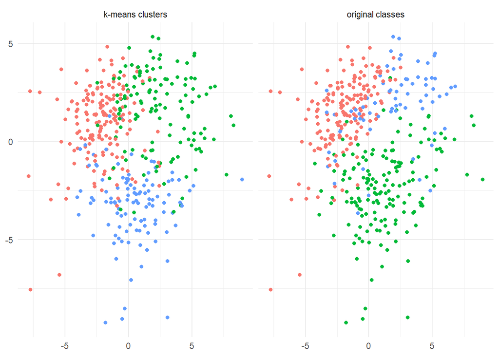

```r
plot_k_means_result_on_PCA(kmC)
```

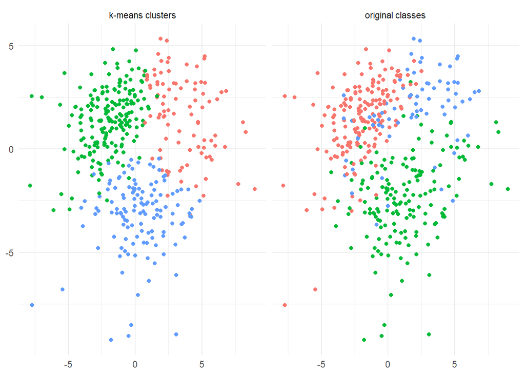

```r
plot_k_means_result_on_PCA(kmZ)
```

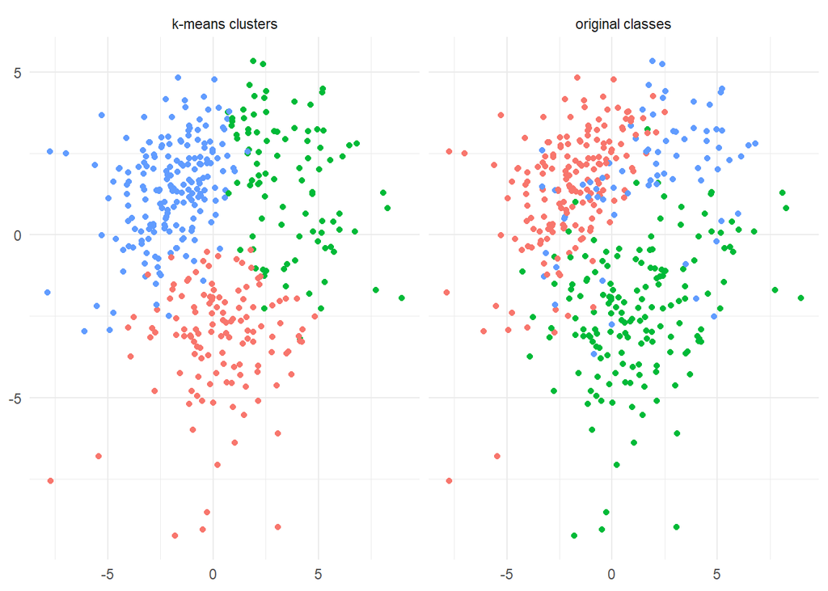

```r
plot_k_means_result_on_PCA(kmP)
```

Try out different k values. Which one would you choose if you didn’t know the number of classes in advance?

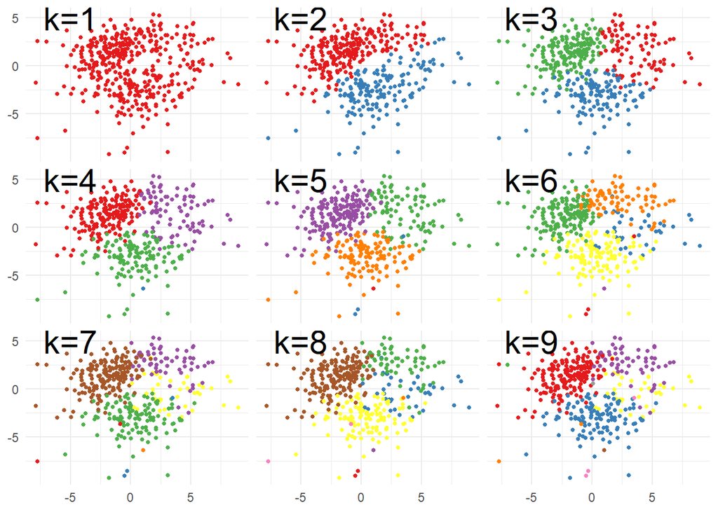

```r
point_colours <- brewer.pal(9, "Set1")
k <- 1:9
res <- lapply(k, function(i) kmeans(pca$x, i, nstart = 50))

plotList <- lapply(k, function(i){
  plot.df <- pca$x %>%
    as.data.frame() %>%
    mutate(class = cuomoClass,
           cluster = as.factor(res[[i]]$cluster))
  ggplot(plot.df, aes(x = PC1, y = PC2)) +
    geom_point(col = point_colours[res[[i]]$cluster], size = 1) +
    annotate("text", x = -5, y = 5, label = paste0("k=", i), size = 8, col = "black")
})

pm <- ggmatrix(plotList, nrow = 3, ncol=3, showXAxisPlotLabels = T, showYAxisPlotLabels = T)
pm
```

### DBSCAN

Run the DBSCAN algorithm with different input and parameters. What do you observe? What does that tell you about the data?

```r
res <- dbscan::dbscan(cuomoData, eps = 0.6, minPts = 10)
res
```

```
## DBSCAN clustering for 408 objects.
## Parameters: eps = 0.6, minPts = 10
## The clustering contains 0 cluster(s) and 408 noise points.
##
##   0
## 408
##
## Available fields: cluster, eps, minPts
```

```r
res <- dbscan::dbscan(cuomoData, eps = 0.1, minPts = 2)
res
```

```
## DBSCAN clustering for 408 objects.
## Parameters: eps = 0.1, minPts = 2
## The clustering contains 0 cluster(s) and 408 noise points.
##
##   0
## 408
##
## Available fields: cluster, eps, minPts
```

```r
res <- dbscan::dbscan(cuomoData, eps = 10, minPts = 2)
res
```

```
## DBSCAN clustering for 408 objects.
## Parameters: eps = 10, minPts = 2
## The clustering contains 5 cluster(s) and 398 noise points.
##
##   0   1   2   3   4   5
## 398   2   2   2   2   2
##
## Available fields: cluster, eps, minPts
```

```r
res <- dbscan::dbscan(cuomoDataCentered, eps = 0.6, minPts = 10)
res
```

```
## DBSCAN clustering for 408 objects.
## Parameters: eps = 0.6, minPts = 10
## The clustering contains 0 cluster(s) and 408 noise points.
##
##   0
## 408
##
## Available fields: cluster, eps, minPts
```

```r
res <- dbscan::dbscan(cuomoDataCentered, eps = 0.1, minPts = 2)
res
```

```
## DBSCAN clustering for 408 objects.
## Parameters: eps = 0.1, minPts = 2
## The clustering contains 0 cluster(s) and 408 noise points.
##
##   0
## 408
##
## Available fields: cluster, eps, minPts
```

```r
res <- dbscan::dbscan(cuomoDataCentered, eps = 10, minPts = 2)
res
```

```
## DBSCAN clustering for 408 objects.
## Parameters: eps = 10, minPts = 2
## The clustering contains 5 cluster(s) and 398 noise points.
##
##   0   1   2   3   4   5
## 398   2   2   2   2   2
##
## Available fields: cluster, eps, minPts
```

```r
res <- dbscan::dbscan(cuomoDataZtransformed, eps = 0.6, minPts = 10)
res
```

```
## DBSCAN clustering for 408 objects.
## Parameters: eps = 0.6, minPts = 10
## The clustering contains 0 cluster(s) and 408 noise points.
##
##   0
## 408
##
## Available fields: cluster, eps, minPts
```

```r
res <- dbscan::dbscan(cuomoDataZtransformed, eps = 0.1, minPts = 2)
res
```

```
## DBSCAN clustering for 408 objects.
## Parameters: eps = 0.1, minPts = 2
## The clustering contains 0 cluster(s) and 408 noise points.
##
##   0
## 408
##
## Available fields: cluster, eps, minPts
```

```r
res <- dbscan::dbscan(cuomoDataZtransformed, eps = 10, minPts = 2)
res
```

```
## DBSCAN clustering for 408 objects.
## Parameters: eps = 10, minPts = 2
## The clustering contains 2 cluster(s) and 404 noise points.
##
##   0   1   2
## 404   2   2
##
## Available fields: cluster, eps, minPts
```

```r
res <- dbscan::dbscan(pca$x, eps = 0.6, minPts = 10)
res
```

```
## DBSCAN clustering for 408 objects.
## Parameters: eps = 0.6, minPts = 10
## The clustering contains 0 cluster(s) and 408 noise points.
##
##   0
## 408
##
## Available fields: cluster, eps, minPts
```

```r
res <- dbscan::dbscan(pca$x, eps = 0.1, minPts = 2)
res
```

```
## DBSCAN clustering for 408 objects.
## Parameters: eps = 0.1, minPts = 2
## The clustering contains 0 cluster(s) and 408 noise points.
##
##   0
## 408
##
## Available fields: cluster, eps, minPts
```

```r
res <- dbscan::dbscan(pca$x, eps = 10, minPts = 2)
res
```

```
## DBSCAN clustering for 408 objects.
## Parameters: eps = 10, minPts = 2
## The clustering contains 2 cluster(s) and 404 noise points.
##
##   0   1   2
## 404   2   2
##
## Available fields: cluster, eps, minPts
```